# Project 003

Nataniel Moreau

2023-03-07

## Part 1: One Tree

#### 01.

I think that precision is the best metric. From my last project: “Assuming each party thinks of Y = 1 as leaning towards themselves, there is not as much consequence from not correctly guessing y = 0 as an incorrect guess still works in the favor of that party. On the other hand, having low precision will lead to misplaced confidence in the strength of their voter base which could lead to missallocation of time and money when campaigning and a bit of a shock come election day when counties assumed to be in favor of you lean the other direction.”

```r
# Part 1: Single Tree -----------------------------------------------------
# splits for CV
elec_cv = elec_data %>% vfold_cv(v = 5)

# create recipe for single tree
elec_recipe_single = recipe(
  i_republican_2016 ~ ., data = elec_data
) %>%
  update_role(c(fips, state, county), new_role = "id variable")

# define tree
elec_tree = decision_tree(
  mode = "classification",
  cost_complexity = tune(),
  tree_depth = 5,
  min_n = tune()
) %>% set_engine("rpart")

# define workflow
single_workflow = workflow() %>%
  add_model(elec_tree) %>%
  add_recipe(elec_recipe_single)

# tune hyper parameters
single_tree_cv = single_workflow %>%
  tune_grid(
    elec_cv,
    grid = expand_grid(
      cost_complexity = seq(0,.15, by = .01),
      min_n = seq(1,10, by = 1)
    ), metrics = metric_set(accuracy, precision))
```

#### 02.

```r
# best models
show_best(single_tree_cv, metric = "accuracy")
```

```
## # A tibble: 5 × 8
##   cost_complexity min_n .metric  .estimator  mean     n std_err .config
##             <dbl> <dbl> <chr>    <chr>      <dbl> <int>   <dbl> <chr>
## 1            0.01     1 accuracy binary     0.960     5 0.00199 Preprocessor1_M…
## 2            0.01     2 accuracy binary     0.960     5 0.00199 Preprocessor1_M…
## 3            0.01     3 accuracy binary     0.960     5 0.00199 Preprocessor1_M…
## 4            0.01     4 accuracy binary     0.960     5 0.00199 Preprocessor1_M…
## 5            0.01     5 accuracy binary     0.960     5 0.00199 Preprocessor1_M…
```

```r
#show_best(single_tree_cv, metric = "precision")
select_best(single_tree_cv, metric = "accuracy")
```

```
## # A tibble: 1 × 3
##   cost_complexity min_n .config
##             <dbl> <dbl> <chr>
## 1            0.01     1 Preprocessor1_Model011
```

```r
select_best(single_tree_cv, metric = "precision")
```

```
## # A tibble: 1 × 3
##   cost_complexity min_n .config
##             <dbl> <dbl> <chr>
## 1               0     9 Preprocessor1_Model009
```

#### 03.

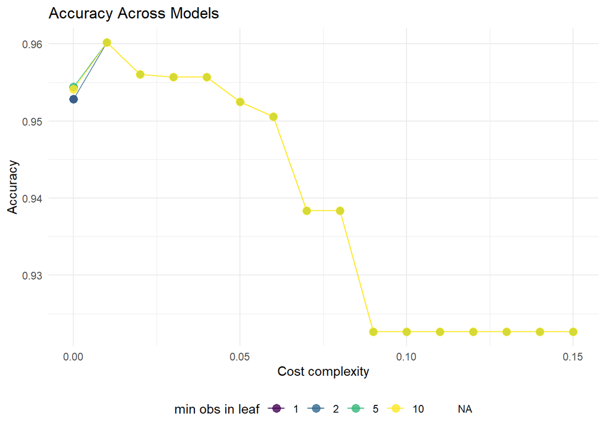

```r
# plot models
single_tree_cv %>%
  collect_metrics() %>%
  filter(.metric == "accuracy") %>%
  ggplot(aes(x=cost_complexity, y=mean,
             color = min_n %>% factor(
               levels = c(1,2,5,10), ordered = T
             ))) +
  geom_line(size = .4)+
  geom_point(size = 3, alpha = .8)+
  labs(color = "min obs in leaf",
       title = "Accuracy Across Models")+
  scale_x_continuous('Cost complexity')+
  scale_y_continuous('Accuracy')+
  theme_minimal()+
  theme(legend.position = 'bottom')
```